# Section 8: Panel Data

Shikhar Singh

November 7, 2019

# Notes from last week

## Placebo check in RD designs

In last week’s problem set, we had to do a placebo check in which we plot the RD estimate, $\widehat{\tau_{RD}}$, for different values of the cut-point. The idea is that if treatment status discontinuously changes only at the cut-point $X = 0$, then the difference in outcomes at other cut-points should be statistically indistinguishable from 0. To this end, the problem set asked us to re-estimate $\widehat{\tau_{RD}}$ for cut-points $c \in (-0.95, -0.90, \cdots,0, \cdots, 0.90, 0.95)$. This assumes the forcing variable, $X_i \in [-1,1]$. Since the dataset codes `DifDPct` between -100 and 100, we first have to transform the forcing variable:

$$\begin{equation}
X_i = \frac{\text{DifDPct}}{100}
\end{equation}$$

Alternatively, redefine the sequence of cut-points to be `seq(-95, 95, 5)`. With this transformation, the placebo check figure looks something like this:

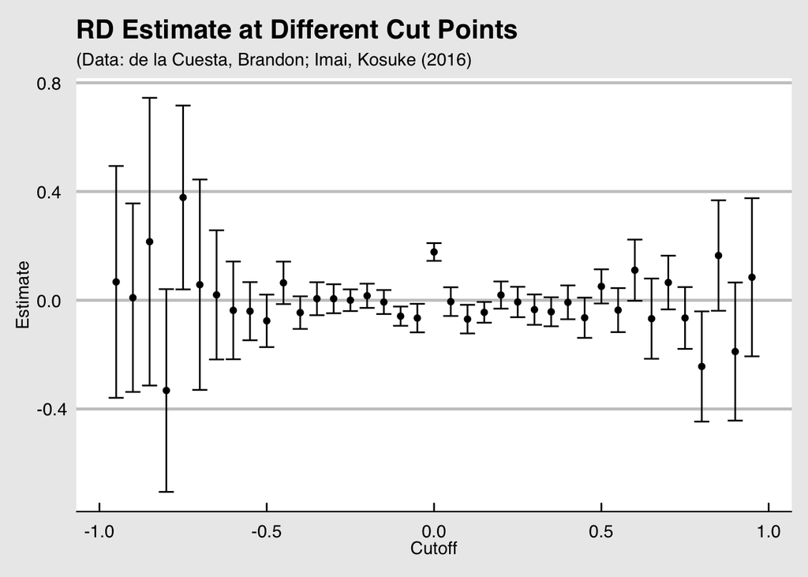

```r
library(tidyverse)
library(rdrobust)
library(rddensity)
library(haven)
library(estimatr)
library(ggthemes)
library(DeclareDesign)
library(knitr)
library(kableExtra)

# Download the dataset
imai <- read_dta("PSET7_RDReplication.dta")

# Subset to observations for which Use = 1,
# and there is no missing values of X,Y, Y_pre
imai_subset <- imai %>%
  filter(Use == 1,!is.na(DifDPct),!is.na(DifDPNxt),!is.na(DifDPPrv)) %>%
  transmute(Y = DifDPNxt/100,
            X = DifDPct/100,
            Z = DifDPct > 0)

# Write a function that returns bias corrected estimate and SE
# given some cut point
rd_function = function(cutpoint){
  output = with(imai_subset, rdrobust(Y,X, c = cutpoint, all = TRUE))
  out = data.frame(output$coef[3], output$se[3])
  names(out) = c("Estimate", "SE")
  return(out)
}

# Use the map function from purrr that applies
# rd_function to every element of cutoffs
cutoffs <- seq(-0.95, 0.95, 0.05)

dat_estimates <-
  map_dfr(.x = cutoffs, .f = rd_function)

dat_estimates$Cutoff = cutoffs

# Make the plot
ggplot(dat_estimates, aes(Cutoff, Estimate)) +
  geom_point() +
  geom_errorbar(aes(ymin = Estimate - 1.96*SE,
                    ymax = Estimate + 1.96*SE)) +
  ggtitle(label = "RD Estimate at Different Cut Points",
          subtitle = "(Data: de la Cuesta, Brandon; Imai, Kosuke (2016)") +
  theme_economist_white(gray_bg = TRUE)
```

## Underpowered Density

Last week’s problem set also had a question about the McCrary density test’s power to detect sorting. To motivate this, we specified a data generating process in `DeclareDesign` such that units right below the cut-point (X values between -0.1 and 0) got a 0.1 “bump” to their X value with a probability $p = 0.1$. Put another way, 10% of the units in that neighborhood sorted above the cut-point.

$$\begin{equation}
\text{Power} = 1 - \text{Type II Error} = 1 - Pr(\text{Not Rejecting} H_0 | H_0 \text{is False})
\end{equation}$$

Where $H_0$ implies no difference in the density of the forcing variable $X$ near the cut-point.

Furthermore, our power calculations showed that given some sorting probability $p$, the test was more likely to detect sorting as $N$ increased. Here is the code and associated figure.

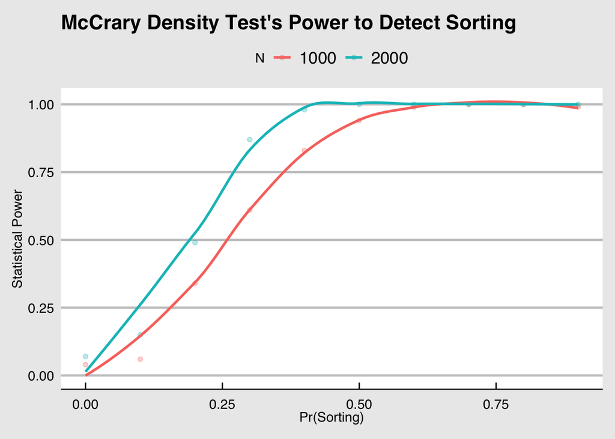

```r
# Alex's McCrary density test function
density_wrapper <-
  function(data) {
  fit <- with(data, rddensity(observed_running_variable))
  data.frame(p = fit$test$p_jk)
}

# Write a function that specifies a design with different N

design_maker = function(units){
  sorting_probability <- 0.1
  rd_design <-
  declare_population(
    N = units,
    true_running_variable = runif(N, -1, 1),
    is_just_below = as.numeric(true_running_variable < 0 & true_running_variable > -0.1),
    would_sort = rbinom(N, 1, sorting_probability),
    observed_running_variable = true_running_variable + 0.1 * is_just_below * would_sort
  ) +
  declare_estimator(handler = density_wrapper)
  return(rd_design)
}

# Calculate power for N = 1000, and 5000

design_1000 <-
  redesign(design_maker(1000),
           sorting_probability = seq(0.0, 0.9, 0.1))

design_2000 <-
  redesign(design_maker(2000),
           sorting_probability = seq(0.0, 0.9, 0.1))


sims1000 <- simulate_design(design_1000, sims = 100)

sims2000 <- simulate_design(design_2000, sims = 100)

results1  = sims1000 %>%
  group_by(sorting_probability) %>%
  summarise(power = mean(p < 0.05)) %>%
  mutate(N = "1000")

results2 = sims2000 %>%
  group_by(sorting_probability) %>%
  summarise(power = mean(p < 0.05)) %>%
  mutate(N = "2000")

sims = rbind(results1,results2)

# Make a figure using ggplot

ggplot(sims, aes(x = sorting_probability, y = power, color = N)) +
  geom_point(alpha = 0.3) +
  geom_smooth(se = FALSE) +
  xlab("Pr(Sorting)") +
  ylab("Statistical Power") +
  ggtitle("McCrary Density Test's Power to Detect Sorting") +
  theme_economist_white(gray_bg = T)
```

# Fixed Effects

Fixed effects or “within” estimators are useful when some group-level invariant characteristics confound the relationship between an outcome $Y$ and some exposure variable $D$. In such cases, the strategy is to discard variation across units and only draw inferences based on variation within units. This way we “difference-out” the invariant characteristic.

To develop this, I will use Angrist and Pischke’s example in which we are interested in the impact of union membership on worker’s earnings.

Let $Y_{i,t}$ be the log earnings of worker $i$ at time $t$, and $D_{i,t}$ an indicator variable that captures union membership of $i$ at time $t$. Assume for a moment that earnings ($Y_{i,t}$) and union membership ($D_{i,t}$) are correlated with:

1. Unobserved characteristics peculiar to each individual, that are fixed or time-invariant. Call this `Ability` or $A_i$
2. An unobserved time shock that affects all individuals in a time period. Call this $\lambda_t$
3. Some observed characteristics that vary across individuals and time periods. Call this $X_{i,t}$

The omitted variable bias here arises from the researcher’s inability to control for $A_i$ and $\lambda_t$. As I shall show, a fixed effects estimation strategy can deal with this problem.

## Assumptions

> **Ignorability:** $D_{it}$ is “ignorable” or “as good as randomly assigned” in some time period t, conditional on $A_i$ and $X_{it}$
> $$\begin{equation}
> \mathbb{E}[Y_{0it} | A_i, X_{it}, t, D_{it}] = \mathbb{E}[Y_{0it} | A_i, X_{it}, t]
> \end{equation}$$

> **Constant Additive Treatment Effect:**
> $$\begin{equation}
> \mathbb{E}[Y_{1it} | A_i, X_{it}, t] = \mathbb{E}[Y_{0it} | A_i, X_{it}, t] + \rho
> \end{equation}$$

When potential outcomes are described in this way, observed outcomes can be written as:

$$\begin{equation}
Y_{it} = \alpha + \lambda_t + \rho D_{it} + A_{i}\gamma + X_{it}\beta + \varepsilon_{it}
\end{equation}$$

Where $\alpha_i = \alpha + A_{i}\gamma$ allows a different intercept for each unit $i$, and is the “fixed effect”. This is algebrically the same as de-meaning each variable by the individual’s average value for that variable:

$$\begin{equation}
(Y_{it} - \overline{Y_{i}}) = (\alpha - \overline{\alpha}) + (\lambda_t - \overline{\lambda}) + \rho (D_{it} - \overline{D_i}) + (A_{i} - \overline{A_i})\gamma + (X_{it} - \overline{X_i}) \beta + (\varepsilon_{it} - \varepsilon_{i})
\end{equation}$$

Now observe that $\alpha$ and $A_i$ are constants, therefore $\alpha = \overline{\alpha}$ and $A_i = \overline{A_i}$.

So we are left with an expression that is purged of $A_i$ (time invariant individual characteristics that confound the association):

$$\begin{equation}
(Y_{it} - \overline{Y_{i}}) = (\lambda_t - \overline{\lambda}) + \rho (D_{it} - \overline{D_i}) + (X_{it} - \overline{X_i}) \beta + (\varepsilon_{it} - \varepsilon_{i})
\end{equation}$$

## Example

To see this in practice, I constructed some fake data using `fabricatr`. I specified `ability` as a time-invariant individual characteristic, `time_trend` as a common shock that affected everyone in a time period, and `time_varying_covariate` as the product of these two quantities and some randomly generated noise. Finally, I defined potential outcomes and union membership as a function of these characteristics. Here is what the data looks like:

```r
set.seed(46)

# Create some data that resembles the Union Membership-Wage case
panel_dat <- fabricate(
  individual = add_level(N = 400, ability = rnorm(N, mean = 0, sd = 0.5)),
  time = add_level(N = 4,
                   time_trend = rnorm(N, mean = 0, sd = 0.5),
                   nest = FALSE),
  observations = cross_levels(
    by = join(individual, time),
    time_varying_covariate = ability*time_trend + rnorm(N, 0, 0.5),
    Y0 = 10.36 + ability + time_trend + time_varying_covariate + rnorm(N, 0, 1),
    Y1 = Y0 + 0.15,
    union_membership = rbinom(N, size = 1, prob = pnorm(ability + time_trend)),
    Y = Y0*(1-union_membership) + Y1*union_membership
  )
)

panel_dat %>% arrange(individual) %>%
  kable(format = "html", digits = 3) %>%
  kable_styling(bootstrap_options = "striped",
                                     full_width = FALSE,
                                     fixed_thead = TRUE) %>%
  scroll_box(width = "750px", height = "250px")
```

| individual | ability | time | time_trend | observations | time_varying_covariate | Y0 | Y1 | union_membership | Y |
| --- | --- | --- | --- | --- | --- | --- | --- | --- | --- |
| 001 | -0.449 | 1 | -0.158 | 0001 | -0.793 | 9.178 | 9.328 | 0 | 9.178 |
| 001 | -0.449 | 2 | 0.369 | 0401 | 0.422 | 10.185 | 10.335 | 1 | 10.335 |
| 001 | -0.449 | 3 | 1.118 | 0801 | -0.532 | 12.336 | 12.486 | 1 | 12.486 |
| 001 | -0.449 | 4 | 0.341 | 1201 | -0.586 | 9.918 | 10.068 | 0 | 9.918 |
| 002 | 0.106 | 1 | -0.158 | 0002 | 0.002 | 10.012 | 10.162 | 0 | 10.012 |
| 002 | 0.106 | 2 | 0.369 | 0402 | 0.159 | 10.040 | 10.190 | 1 | 10.190 |
| 002 | 0.106 | 3 | 1.118 | 0802 | 0.578 | 11.885 | 12.035 | 1 | 12.035 |
| 002 | 0.106 | 4 | 0.341 | 1202 | 0.684 | 11.354 | 11.504 | 1 | 11.504 |
| 003 | -0.364 | 1 | -0.158 | 0003 | -0.346 | 9.581 | 9.731 | 1 | 9.731 |
| 003 | -0.364 | 2 | 0.369 | 0403 | -1.039 | 9.257 | 9.407 | 1 | 9.407 |
| 003 | -0.364 | 3 | 1.118 | 0803 | -0.188 | 10.978 | 11.128 | 1 | 11.128 |
| 003 | -0.364 | 4 | 0.341 | 1203 | 1.103 | 11.579 | 11.729 | 1 | 11.729 |
| 004 | 0.618 | 1 | -0.158 | 0004 | -0.183 | 10.656 | 10.806 | 1 | 10.806 |
| 004 | 0.618 | 2 | 0.369 | 0404 | 0.438 | 12.618 | 12.768 | 0 | 12.618 |
| 004 | 0.618 | 3 | 1.118 | 0804 | 0.537 | 11.446 | 11.596 | 1 | 11.596 |
| 004 | 0.618 | 4 | 0.341 | 1204 | 0.154 | 11.612 | 11.762 | 1 | 11.762 |
| 005 | 0.584 | 1 | -0.158 | 0005 | -0.754 | 10.794 | 10.944 | 0 | 10.794 |
| 005 | 0.584 | 2 | 0.369 | 0405 | 0.139 | 11.380 | 11.530 | 0 | 11.380 |
| 005 | 0.584 | 3 | 1.118 | 0805 | 1.254 | 13.389 | 13.539 | 1 | 13.539 |
| 005 | 0.584 | 4 | 0.341 | 1205 | -0.337 | 11.255 | 11.405 | 1 | 11.405 |
| 006 | -0.311 | 1 | -0.158 | 0006 | 0.324 | 9.599 | 9.749 | 0 | 9.599 |
| 006 | -0.311 | 2 | 0.369 | 0406 | -0.881 | 10.117 | 10.267 | 0 | 10.117 |
| 006 | -0.311 | 3 | 1.118 | 0806 | -0.269 | 10.011 | 10.161 | 1 | 10.161 |
| 006 | -0.311 | 4 | 0.341 | 1206 | 0.419 | 9.610 | 9.760 | 0 | 9.610 |
| 007 | 0.215 | 1 | -0.158 | 0007 | -0.030 | 9.525 | 9.675 | 1 | 9.675 |
| 007 | 0.215 | 2 | 0.369 | 0407 | -0.027 | 11.325 | 11.475 | 1 | 11.475 |
| 007 | 0.215 | 3 | 1.118 | 0807 | -0.111 | 12.464 | 12.614 | 1 | 12.614 |
| 007 | 0.215 | 4 | 0.341 | 1207 | -0.157 | 11.065 | 11.215 | 1 | 11.215 |
| 008 | 0.360 | 1 | -0.158 | 0008 | -0.182 | 11.153 | 11.303 | 0 | 11.153 |
| 008 | 0.360 | 2 | 0.369 | 0408 | 0.783 | 10.995 | 11.145 | 1 | 11.145 |

[output cut: 1570 more lines]

Note that I build in constant, additive effects:

```r
# Check to see the true effect is 0.15

panel_dat %>% group_by(individual) %>%
  summarise(within_person = mean(Y1) - mean(Y0)) %>%
  summarise(Overall = mean(within_person))
```

```
## # A tibble: 1 x 1
##   Overall
##     <dbl>
## 1    0.15
```

### Exercise I

We will now assess different estimation strategies. Please `set.seed(46)` and create the data using my code. Next, estimate the following models:

- A naive regression of `Y` on `union_membership`
- A regression of `Y` on `union_membership` that controls for `time_varying_covariate`
- A “within-person” or fixed-effects model that allows a separate intercept for each individual (i.e. $N-1$ dummy variables)
- A “two-way fixed effects” model that restricts the comparison to “within-person” and “within-time period”.

How do these estimation strategies fare? Which strategy comes closest to the true effect, $\rho = 0.15$?

**Answer:**

Here is the regression output from my code:

```r
# Different estimation strategies

model1 = lm_robust(Y ~ union_membership,
                   data = panel_dat) %>%
                   extract.lm_robust(include.ci = FALSE)

model2 = lm_robust(Y ~ union_membership + time_varying_covariate,
                   data = panel_dat) %>%
                   extract.lm_robust(include.ci = FALSE)

model3 = lm_robust(
  Y ~ union_membership + time_varying_covariate,
  fixed_effects = ~ individual,
  data = panel_dat
  ) %>%
  extract.lm_robust(include.ci = FALSE)

model4 = lm_robust(
  Y ~ union_membership + time_varying_covariate,
  fixed_effects = ~ individual + time,
  data = panel_dat
  ) %>%
  extract.lm_robust(include.ci = FALSE)


texreg::htmlreg(
  list(model1, model2, model3, model4),
  stars = c(0.001, 0.01, 0.05),
  custom.coef.names = c("(Intercept)", "Union Membership", "Time Varying Covariate"),
  custom.model.names = c("Baseline", "With Controls", "Individual FEs", "Time+Indv FEs"),
  digits = 3,
  caption = "Fixed Effects Estimation"
  )
```

Fixed Effects Estimation

|  | **Baseline** | **With Controls** | **Individual FEs** | **Time+Indv FEs** |  |
| --- | --- | --- | --- | --- | --- |
| (Intercept) | 10.308*** | 10.398*** |  |  |  |
|  | (0.054) | (0.050) |  |  |  |
| Union Membership | 0.909*** | 0.751*** | 0.577*** | 0.165* |  |
|  | (0.070) | (0.062) | (0.071) | (0.069) |  |
| Time Varying Covariate |  | 1.236*** | 0.954*** | 0.909*** |  |
|  |  | (0.054) | (0.060) | (0.052) |  |
| R<sup>2</sup> | 0.091 | 0.331 | 0.543 | 0.633 |  |
| Adj. R<sup>2</sup> | 0.090 | 0.330 | 0.390 | 0.508 |  |
| Num. obs. | 1600 | 1600 | 1600 | 1600 |  |
| RMSE | 1.378 | 1.182 | 1.128 | 1.013 |  |
| p < 0.001, p < 0.01, p < 0.05 |  |  |  |  |  |

## Partial Regression Framework

> Claim: Including fixed effects is algebrically the same as de-meaning each variable.

To show this, I go through the regression anatomy of a fixed effects model. I will show that:

- When we residualize an outcome, or exposure variable, we remove all the variation due to time-invariant characteristics ($A_i$), common shocks in a time period ($\lambda_t$), and time-variant characteristics ($X_{it}$). The remaining variation in `earnings` and `union_membership` is entirely within-person. We leverage this variation to see how changes in `union_membership` affect `earnings`.
- The estimate from a “res-res” regression is exactly equal to the two-way fixed effects coefficient $\rho$.

Here is what the residualized values look like:

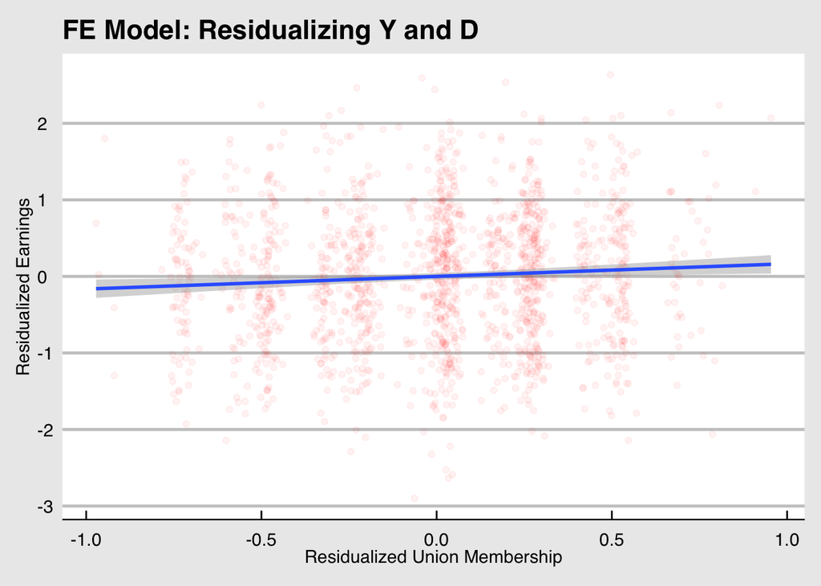

```r
# Partial Regression Approach

# Residualize Y and Union Membership
fit1 = lm_robust(Y ~ time_varying_covariate +
                   as.factor(individual) +
                   as.factor(time),
                   data = panel_dat)

fit2 = lm_robust(
  union_membership ~ time_varying_covariate +
  as.factor(individual) +
  as.factor(time),
  data = panel_dat
  )

panel_dat$Y_resid = panel_dat$Y - fit1$fitted.values

panel_dat$D_resid = panel_dat$union_membership - fit2$fitted.values

# Visualize the residualized data

ggplot(panel_dat, aes(x = D_resid, y = Y_resid)) +
  geom_point(color = "red", alpha = 0.05) +
  geom_smooth(method = "lm_robust") +
  xlab("Residualized Union Membership") +
  ylab("Residualized Earnings") +
  ggtitle("FE Model: Residualizing Y and D") +
  theme_economist_white(gray_bg = TRUE)
```

And here are the results from a regression of $\tilde{Y_{it}} \sim \tilde{D_{it}}$:

```r
# Running the regression

model5 = lm_robust(Y_resid ~ D_resid, panel_dat) %>%
  extract.lm_robust(include.ci = FALSE)

texreg::htmlreg(
  model5,
  stars = c(0.001, 0.01, 0.05),
  custom.coef.names = c("(Intercept)", "Union Membership"),
  custom.model.names = c("2 Way Fixed Effects + Controls"),
  digits = 3,
  caption = "Recovering FE Estimates using FWL Theorem"
  )
```

Recovering FE Estimates using FWL Theorem

|  | **2 Way Fixed Effects + Controls** |  |
| --- | --- | --- |
| (Intercept) | -0.000 |  |
|  | (0.022) |  |
| Union Membership | 0.165** |  |
|  | (0.060) |  |
| R<sup>2</sup> | 0.005 |  |
| Adj. R<sup>2</sup> | 0.004 |  |
| Num. obs. | 1600 |  |
| RMSE | 0.876 |  |
| p < 0.001, p < 0.01, p < 0.05 |  |  |

## Regression Weights

We know from Aronow and Samii (2016) that an ordinary least squares regression weights observations by the conditional variance of treatment. This has the following implication for a fixed effects setup:

> OLS drops all individuals whose union membership status, $D_{it}$, does not change in the study period. This is because $w_{ols} \propto Var(D_{it})$ and these individuals have $Var(D_{it}) = 0$

By implication, the treatment effect estimate ($\rho$) is the same when we use the full dataset, and when we subset to only those individuals with $Var(D_{it}) \neq 0$.

However, there is a caveat to this. If we include covariates in the fixed effects model, individuals with $Var(D_{it}) = 0$ may *not* be entirely dropped from the estimation procedure. This is because the residualized values of $D_{it}$ for an individual may not all be the same. Consequently, $Var(\tilde{D_{it}})$ is not exactly zero. I show this in two ways:

1. Using the residuals, $\tilde{D_{it}}$, from the regression anatomy case (above), I estimate $Var(\tilde{D_{it}})$ for each individual. I then compare this to the $Var(D_{it})$.
2. I plot these two quantities separately for those who might be considered `Dropped` ($Var(D_{it}) = 0$), and those `Included` in the fixed effects estimation:

```r
# REGRESSION WEIGHTS

cond_variance_dat = panel_dat %>% group_by(individual) %>%
  summarise(
  var_unionmembership = var(union_membership),
  var_Dresid = var(D_resid)
  )

cond_variance_dat %>%
  kable(format = "html",
        col.names = c("Individual", "Var(Union Membership)", "Var(D_resid)"),
        digits = 3
        ) %>%
  kable_styling(bootstrap_options = "striped",
                                     full_width = FALSE,
                                     fixed_thead = TRUE) %>%
  scroll_box(width = "750px", height = "250px")
```

| Individual | Var(Union Membership) | Var(D_resid) |
| --- | --- | --- |
| 001 | 0.333 | 0.236 |
| 002 | 0.250 | 0.164 |
| 003 | 0.000 | 0.028 |
| 004 | 0.250 | 0.265 |
| 005 | 0.333 | 0.251 |
| 006 | 0.250 | 0.134 |
| 007 | 0.000 | 0.027 |
| 008 | 0.250 | 0.160 |
| 009 | 0.000 | 0.026 |
| 010 | 0.333 | 0.236 |
| 011 | 0.333 | 0.222 |
| 012 | 0.250 | 0.168 |
| 013 | 0.000 | 0.035 |
| 014 | 0.250 | 0.149 |
| 015 | 0.333 | 0.241 |
| 016 | 0.333 | 0.228 |
| 017 | 0.250 | 0.250 |
| 018 | 0.333 | 0.247 |
| 019 | 0.333 | 0.342 |
| 020 | 0.333 | 0.208 |
| 021 | 0.250 | 0.278 |
| 022 | 0.333 | 0.482 |
| 023 | 0.250 | 0.263 |
| 024 | 0.000 | 0.020 |
| 025 | 0.333 | 0.241 |
| 026 | 0.250 | 0.140 |
| 027 | 0.333 | 0.230 |
| 028 | 0.000 | 0.028 |
| 029 | 0.000 | 0.033 |
| 030 | 0.250 | 0.146 |

[output cut: 370 more lines]

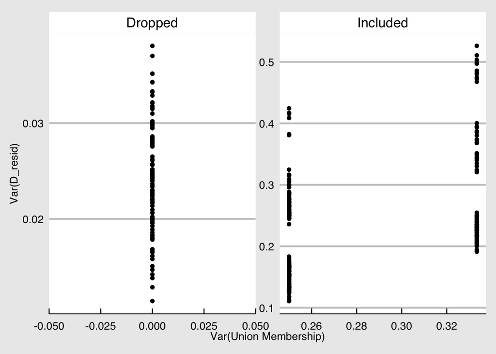

```r
# Plots

cond_variance_dat = cond_variance_dat %>%
  mutate(
    Dropped = if_else(var_unionmembership == 0, "Dropped", "Included")
  )

ggplot(cond_variance_dat, aes(x = var_unionmembership, y = var_Dresid)) +
  geom_point() +
  xlab("Var(Union Membership)") +
  ylab("Var(D_resid)") +
  theme_economist_white(gray_bg = TRUE) +
  facet_wrap(~Dropped, scales = "free")
```

# Difference in Difference Estimator

> The fixed effects strategy requires panel data, that is, repeated observations on the same individual (or firms, or whatever the unit of observation might be). Often, however, the regressor of interest varies only at a more aggregate or group level … The source of OVB [omitted variable bias in such cases] must be unobserved variables at the [aggregate level]. This leads to the difference-in-difference strategy… DD is a version of fixed effects estimation using aggregate data. (Angrist and Pischke 2009:227-8)

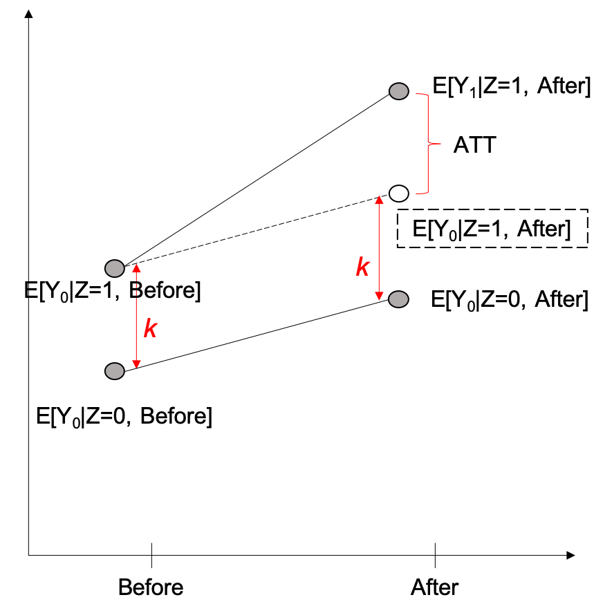

Figure 1: Difference in Difference Setup

## Estimand

> The quantity of interest is the average treatment effect in the treated group (ATT)
> $$\begin{equation}
> \mathbb{E}[Y_i(1) - Y_i(0) | Z = 1, \text{Time = After}]
> \end{equation}$$

## Assumption

> **Parallel Trends** is the identification assumption necessary to estimate this quantity. Formally:
> $$\begin{equation}
> \mathbb{E}[Y_i(0) | Z = 1, \text{Time = After}] - \mathbb{E}[Y_i(0) | Z = 1, \text{Time = Before}] \\\
> = \mathbb{E}[Y_i(0) | Z = 0, \text{Time = After}] - \mathbb{E}[Y_i(0) | Z = 0, \text{Time = Before}]
> \end{equation}$$
> If we re-arrange the terms, another way of saying this is
> $$\begin{equation}
> \mathbb{E}[Y_i(0) | Z = 1, \text{Time = After}] - \mathbb{E}[Y_i(0) | Z = 0, \text{Time = After}] \\\
> = \mathbb{E}[Y_i(0) | Z = 1, \text{Time = Before}] - \mathbb{E}[Y_i(0) | Z = 0, \text{Time = Before}] \\\
> = k
> \end{equation}$$

In terms of Figure 1, this assumption says that the difference in average untreated potential outcomes (E[$Y_0$]) of the treatment and control groups is the same “before” and “after” (i.e. $k$).

Note that this assumption is **not** empirically verifiable. Two groups that are trending pre-intervention, may or may not satisfy this criterion. It is highly likely that if their outcomes trend, the assumption might hold. However, the absence of parallel trends in the pre-intervention period is *not* evidence against this assumption.

## Estimation and Visualization

I will motivate this section with the Card and Kreuger (1994) study that looks at the impact of minimum wages on youth employment. In this study, there are two groups — New Jersey ($Z=1$) and Pennsylvania ($Z=0$) — and two time periods — $T_0$ when both states had similar minimum wage laws, and $T_1$ when New Jersey raised the minimum wage. We can estimate difference-in-differences using an ordinary least squares regression of the type:

$$\begin{equation}
\text{Employment} = \beta_0 + \beta_1 (I_{\text{New Jersey}}) + \beta_2 (I_{\text{After}}) + \beta_3 (I_{\text{New Jersey}} \times I_{\text{After}}) + \varepsilon
\end{equation}$$

Here is the data from the replication files. I used `tidyverse` to “tidy” the data.

```r
card = read_dta("card_krueger.dta")

# Select the relevant columns for the analysis

card = card %>% select(
  emptot, emptot2, nj, pa,
  bk, kfc, roys, wendys
) %>%
  mutate(
    ID = row_number(),
    State = if_else(nj == 1, "New Jersey", "PA")
  ) %>%
  rename(
    Time1 = emptot,
    Time2 = emptot2
  )

# Tidying the data

card = card %>%
  gather(key = "Time", value = "Outcome", -c(ID,State, nj,pa,bk,kfc,roys,wendys))

card = card %>%
  mutate(Time = recode(Time, `Time1` = 0, `Time2` = 1))

card %>% arrange(ID) %>% kable(format = "html") %>%
  kable_styling(bootstrap_options = "striped",
                                     full_width = FALSE,
                                     fixed_thead = TRUE) %>%
  scroll_box(width = "750px", height = "250px")
```

| nj | pa | bk | kfc | roys | wendys | ID | State | Time | Outcome |
| --- | --- | --- | --- | --- | --- | --- | --- | --- | --- |
| 0 | 1 | 1 | 0 | 0 | 0 | 1 | PA | 0 | 40.50 |
| 0 | 1 | 1 | 0 | 0 | 0 | 1 | PA | 1 | 24.00 |
| 0 | 1 | 0 | 1 | 0 | 0 | 2 | PA | 0 | 13.75 |
| 0 | 1 | 0 | 1 | 0 | 0 | 2 | PA | 1 | 11.50 |
| 0 | 1 | 0 | 1 | 0 | 0 | 3 | PA | 0 | 8.50 |
| 0 | 1 | 0 | 1 | 0 | 0 | 3 | PA | 1 | 10.50 |
| 0 | 1 | 0 | 0 | 0 | 1 | 4 | PA | 0 | 34.00 |
| 0 | 1 | 0 | 0 | 0 | 1 | 4 | PA | 1 | 20.00 |
| 0 | 1 | 0 | 0 | 0 | 1 | 5 | PA | 0 | 24.00 |
| 0 | 1 | 0 | 0 | 0 | 1 | 5 | PA | 1 | 35.50 |
| 0 | 1 | 0 | 0 | 0 | 1 | 6 | PA | 0 | 20.50 |
| 0 | 1 | 0 | 0 | 0 | 1 | 6 | PA | 1 | NA |
| 0 | 1 | 1 | 0 | 0 | 0 | 7 | PA | 0 | 70.50 |
| 0 | 1 | 1 | 0 | 0 | 0 | 7 | PA | 1 | 29.00 |
| 0 | 1 | 1 | 0 | 0 | 0 | 8 | PA | 0 | 23.50 |
| 0 | 1 | 1 | 0 | 0 | 0 | 8 | PA | 1 | 36.50 |
| 0 | 1 | 0 | 1 | 0 | 0 | 9 | PA | 0 | 11.00 |
| 0 | 1 | 0 | 1 | 0 | 0 | 9 | PA | 1 | 11.00 |
| 0 | 1 | 0 | 1 | 0 | 0 | 10 | PA | 0 | 9.00 |
| 0 | 1 | 0 | 1 | 0 | 0 | 10 | PA | 1 | 8.50 |
| 0 | 1 | 0 | 0 | 1 | 0 | 11 | PA | 0 | 15.50 |
| 0 | 1 | 0 | 0 | 1 | 0 | 11 | PA | 1 | 17.50 |
| 0 | 1 | 1 | 0 | 0 | 0 | 12 | PA | 0 | 58.00 |
| 0 | 1 | 1 | 0 | 0 | 0 | 12 | PA | 1 | 29.00 |
| 0 | 1 | 1 | 0 | 0 | 0 | 13 | PA | 0 | 26.50 |
| 0 | 1 | 1 | 0 | 0 | 0 | 13 | PA | 1 | 30.50 |
| 0 | 1 | 1 | 0 | 0 | 0 | 14 | PA | 0 | 28.50 |
| 0 | 1 | 1 | 0 | 0 | 0 | 14 | PA | 1 | 26.00 |
| 0 | 1 | 1 | 0 | 0 | 0 | 15 | PA | 0 | 13.50 |
| 0 | 1 | 1 | 0 | 0 | 0 | 15 | PA | 1 | 18.00 |

[output cut: 790 more lines]

Here is a `ggplot` of the data, overlaid with the summary statistics (group means and trend lines):

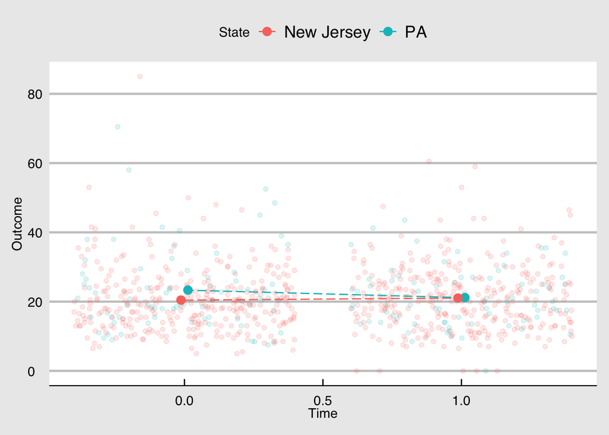

```r
# Creating group level summaries

card_state_summaries = card %>% group_by(State, Time) %>%
  summarise(Outcome = mean(Outcome, na.rm = T))

# Visualize the data

ggplot(card, aes(x = Time, y = Outcome, color = State)) +
  geom_point(position = "jitter",
             alpha = 0.15) +
  geom_line(stat='summary', fun.y='mean', linetype = "longdash") +
  geom_point(card_state_summaries,
             mapping = aes(x = Time, y = Outcome, color = State),
             size = 3, shape = 19, position = position_dodge(width = 0.05)) +
  theme_economist_white(gray_bg = TRUE)
```

And a table that produces the coefficients from a regression with the above specification:

```r
# Estimation

dif_model1 = lm_robust(Outcome ~ nj + Time + nj*Time,  data = card) %>%
  extract.lm_robust(include.ci = FALSE)

dif_model2 = lm_robust(Outcome ~ nj + Time + nj*Time,
                      clusters = ID,
                      data = card) %>%
  extract.lm_robust(include.ci = FALSE)

texreg::htmlreg(list(dif_model1, dif_model2),
                stars = c(0.001, 0.01, 0.05),
                custom.coef.names = c("(Intercept)", "New Jersey", "Time",
  "New Jersey x Time"),
  custom.model.names = c("Baseline", "Clustered SEs"),
  digits = 3,
  caption = "Card and Krueger (1994)"
  )
```

Card and Krueger (1994)

|  | **Baseline** | **Clustered SEs** |  |
| --- | --- | --- | --- |
| (Intercept) | 23.331*** | 23.331*** |  |
|  | (1.351) | (1.351) |  |
| New Jersey | -2.892* | -2.892* |  |
|  | (1.444) | (1.444) |  |
| Time | -2.166 | -2.166 |  |
|  | (1.648) | (1.222) |  |
| New Jersey x Time | 2.754 | 2.754* |  |
|  | (1.801) | (1.310) |  |
| R<sup>2</sup> | 0.007 | 0.007 |  |
| Adj. R<sup>2</sup> | 0.004 | 0.004 |  |
| Num. obs. | 794 | 794 |  |
| RMSE | 9.406 | 9.406 |  |
| p < 0.001, p < 0.01, p < 0.05 |  |  |  |

## Exercise 2

Using the regression table, can you tell me what the following quantities are?

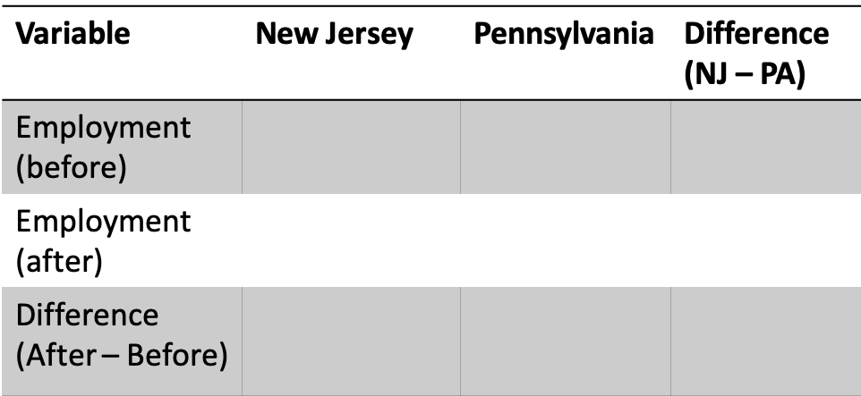

Figure 2: Card and Krueger, Table 3

**Answers:**

Here is what I get:

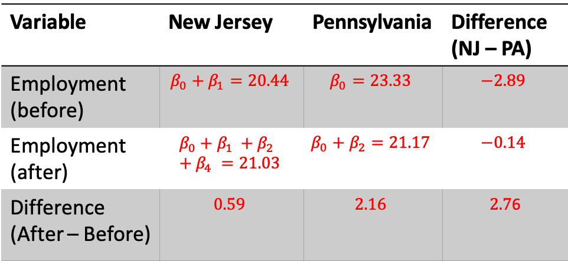

Figure 3: Card and Krueger, Table 3

# Relaxing Parallel Trends

We know that the difference-in-difference estimator is:

$$\begin{equation}
\mathbb{E}[Y_i(1) | Z = 1, \text{Time = After}] - \mathbb{E}[Y_i(0) | Z = 1, \text{Time = Before}] \\\
- (\mathbb{E}[Y_i(0) | Z = 0, \text{Time = After}] - \mathbb{E}[Y_i(0) | Z = 0, \text{Time = Before}])
\end{equation}$$

Consider a more general form of this:

$$\begin{equation}
(\Delta \text{treatment group's Y}) - \alpha (\Delta \text{control group's Y})
\end{equation}$$

In a DD specification, $\alpha = 1$. However, $\alpha$ could also be greater than or less than 1. For example, in the figure below I show that when $\alpha < 1$, the two groups converge over time; and when $\alpha >1$ they diverge over time.

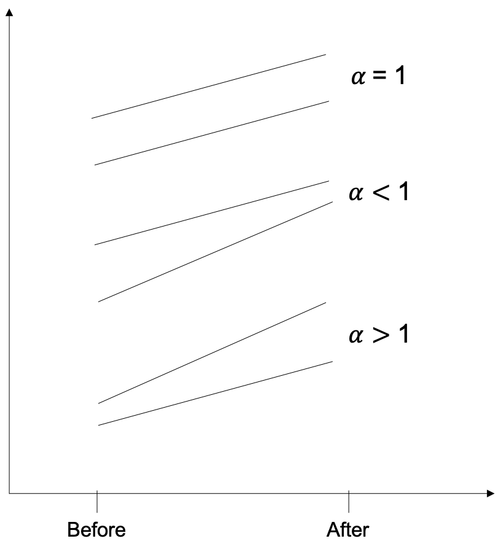

Figure 3: Morgan and Winship, Figure 11.6

Morgan and Winship suggest that identification is possible even when there is a non-parallel trend. In “analysis of covariance” for example, we assume:

$$\begin{equation}
\mathbb{E}[Y_i(0) | Z = 1, \text{Time = Before}] - \mathbb{E}[Y_i(0) | Z = 0, \text{Time = Before}] = k
\end{equation}$$

and

$$\begin{equation}
\mathbb{E}[Y_i(0) | Z = 1, \text{Time = After}] - \mathbb{E}[Y_i(0) | Z = 0, \text{Time = After}] = k \times \alpha
\end{equation}$$

Crucially, $\alpha$ which captures the “between-group shrinkage [in each time period]” is the partial correlation between $Y_{it}$ and $Y_{i,t-1}$. More concretely, it is the coefficient on the lagged dependent variable in a regression of the type:

$$\begin{equation}
Y_{it} = b_0 + \alpha(Y_{i,t-1}) + b_1 (D_{i}) + \varepsilon_{i}
\end{equation}$$

Since this can be estimated, we might use the pre-intervention data (“before”) to get $\alpha$, then use this to build the counterfactual $\mathbb{E}[Y_i(0) | Z = 1, \text{Time = After}]$.